# Lab2-parte3

Bruna Barbosa

# Tipos de filme de Matt Damon

Usaremos dados do [Rotten Tomatoes](https://www.rottentomatoes.com) sobre os filmes de Matt Damon.

```r
from_page <- read_html("https://www.rottentomatoes.com/celebrity/matt_damon/") %>%
    html_node("#filmographyTbl") %>% # A sintaxe da expressão é de um seletor à lá JQuery: https://rdrr.io/cran/rvest/man/html_nodes.html
    html_table(fill=TRUE) %>% # Faz parse
    as.tibble()

filmes = from_page %>%
    filter(RATING != "No Score Yet",
           `BOX OFFICE` != "—",
           CREDIT != "Executive Producer") %>%
    mutate(RATING = as.numeric(gsub("%", "", RATING)),
           `BOX OFFICE` = as.numeric(gsub("[$|M]", "", `BOX OFFICE`))) %>%
    filter(`BOX OFFICE` >= 1) # Tem dois filmes que não parecem ter sido lançados no mundo todo
```

# Rating

Dentre os 40 filmes estrelados por Matt Damon é possivel notar uma grande variaçao entre as notas no rotten tomatoes. Nao ha concentraçao de pontos visiveis.

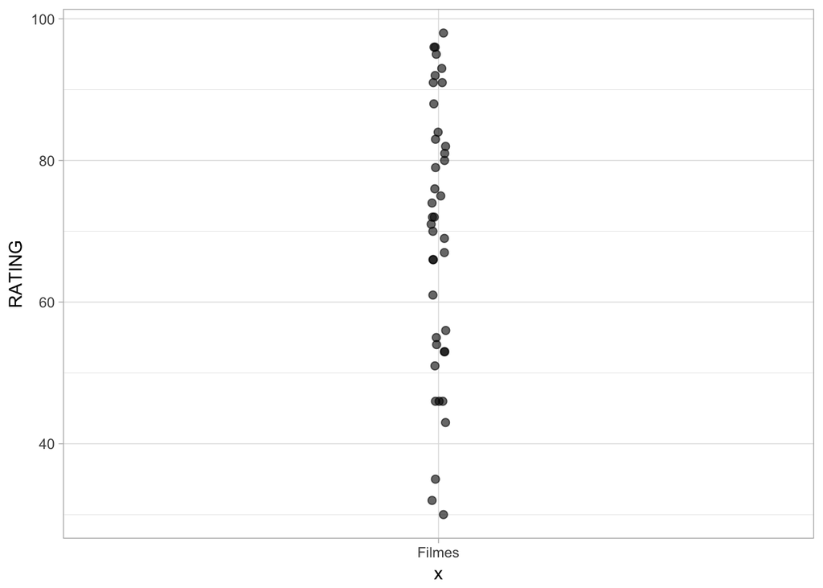

```r
filmes %>%
    ggplot(aes(x = "Filmes", y = RATING)) +
    geom_jitter(width = .01, height = 0, size = 2, alpha = .6)
```

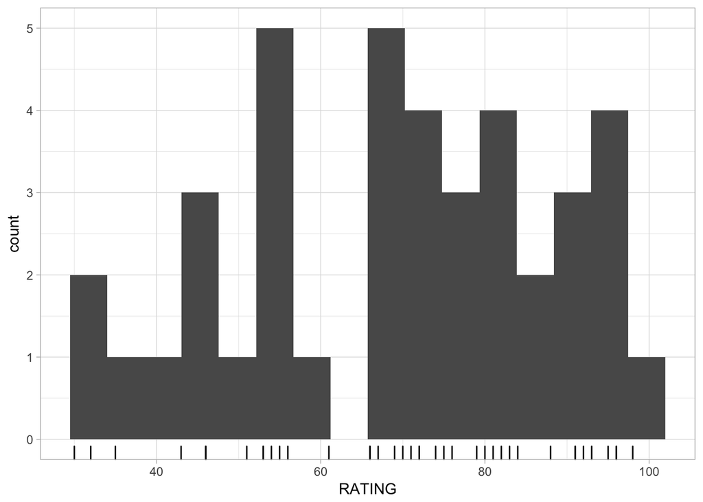

```r
filmes %>%
    ggplot(aes(x = RATING)) +
    geom_histogram(bins = 16) +
    geom_rug()
```

# Renda

Para a renda do filme, observar uma escala linear ou logarítmica levam a conclusões diferentes. Quanto a rentabilidade do filme, Matt Damon atuou em varios filmes de alta rentabilidade.

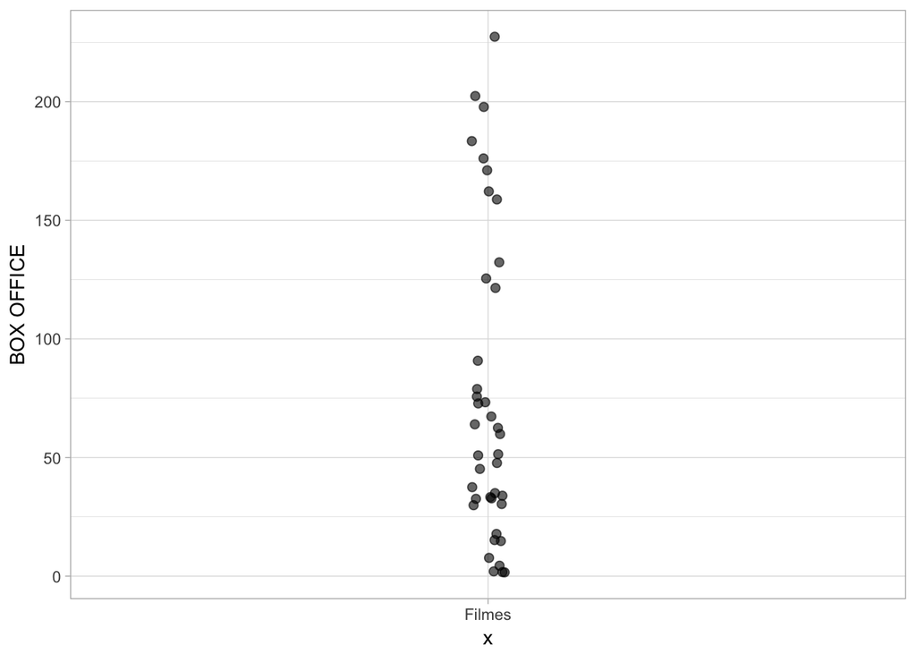

```r
filmes %>%
    ggplot(aes(x = "Filmes", y = `BOX OFFICE`)) +
    geom_jitter(width = .02, height = 0, size = 2, alpha = .6)
```

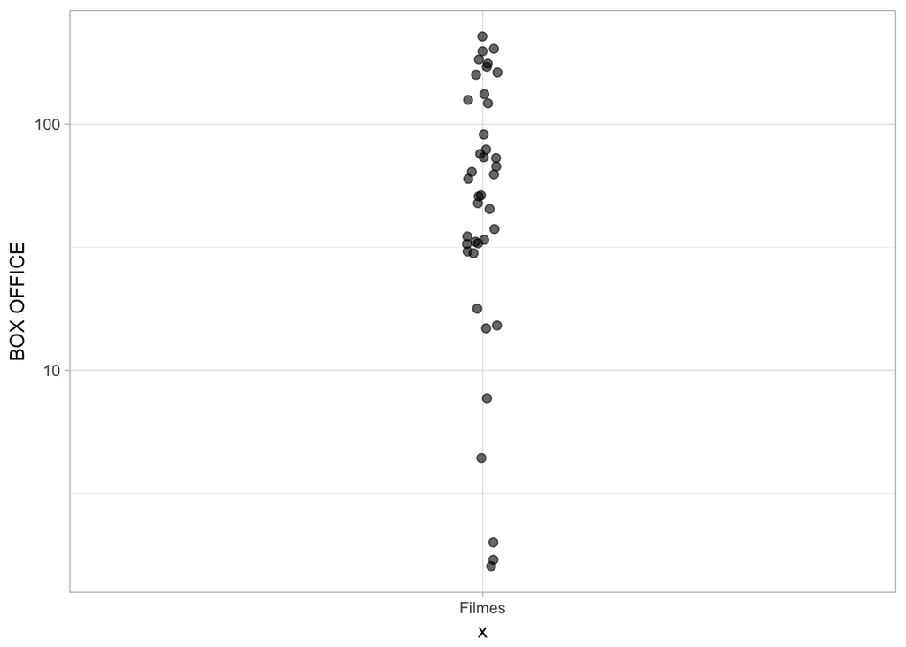

```r
filmes %>%
    ggplot(aes(x = "Filmes", y = `BOX OFFICE`)) +
    geom_jitter(width = .02, height = 0, size = 2, alpha = .6) +
    scale_y_log10()
```

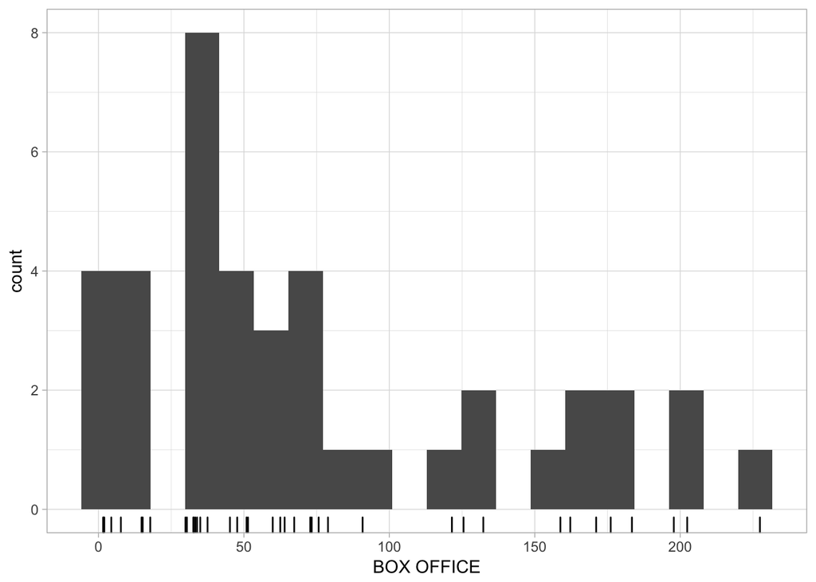

```r
filmes %>%
    ggplot(aes(x = `BOX OFFICE`)) +
    geom_histogram(bins = 20) +
    geom_rug()
```

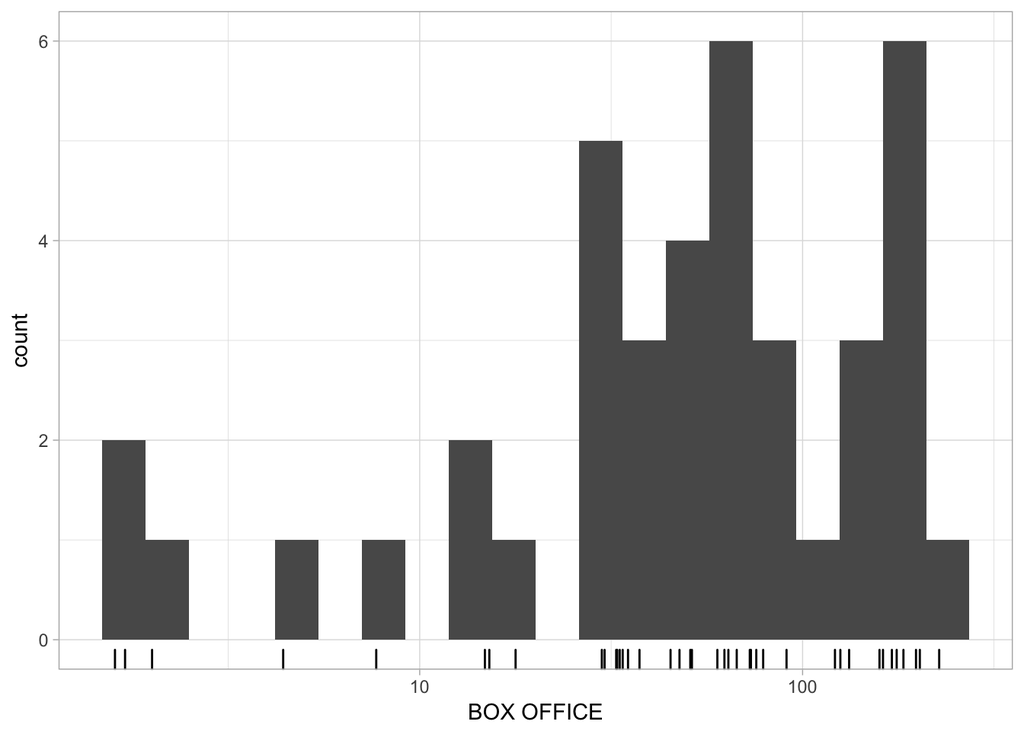

```r
filmes %>%
    ggplot(aes(x = `BOX OFFICE`)) +
    geom_histogram(bins = 20) +
    scale_x_log10() +
    geom_rug()
```

## Duas dimensões - RATING X BOX OFFICE

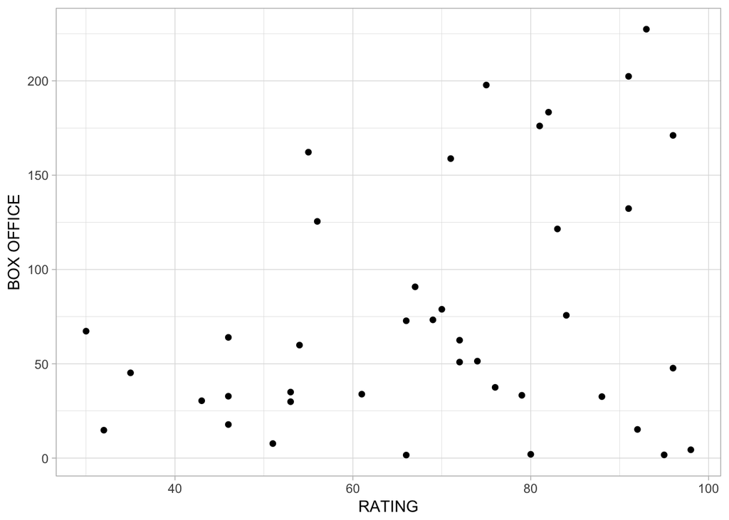

```r
p = filmes %>%
    ggplot(aes(x = RATING, y = `BOX OFFICE`, label = TITLE)) +
    geom_point()
p
```

```r
#ggplotly(p)
```

Como sempre, o algoritmo encontra grupos. No caso, parecem até bem separados. Vamos visualizá-los:

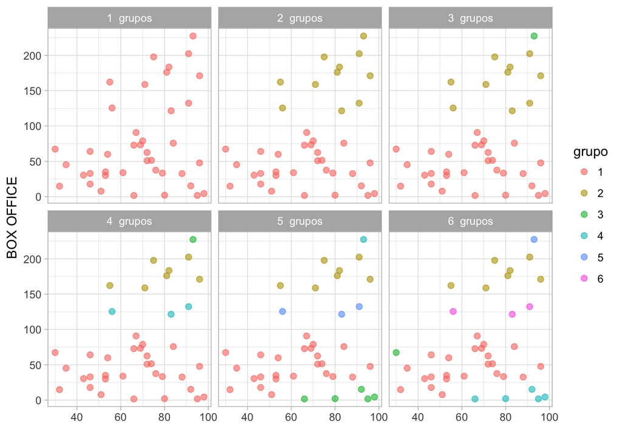

O agrupamento está acontecendo todo em função de BOX OFFICE, apenas. Como as escalas são diferentes, BOX OFFICE domina qualquer cálculo de distância euclidiana.

Solução: standardize (aka scale).

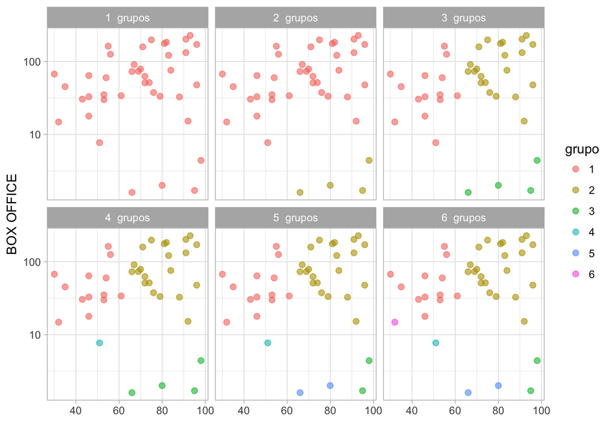

O algoritmo consegue definir clusters bem definidos no grupo 3, esses pontos tem semelhanças considerando o rating obtido e a renda dos filmes.

# Agrupamento - kmeans

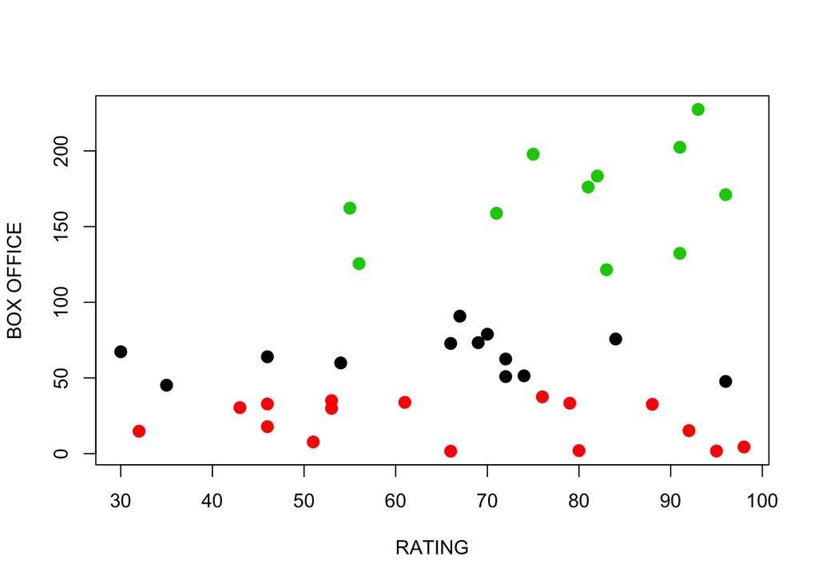

```r
#k <- kmeans(filmes, 3)
dat <- filmes[,c(1,4)]

#plot(dat, pch = 20, cex = 2)
set.seed(7)
km1 <- kmeans(dat, 3)
plot(dat, col = km1$cluster, pch = 20, cex = 2)
```

# Agrupamento - kmeans (standardize)

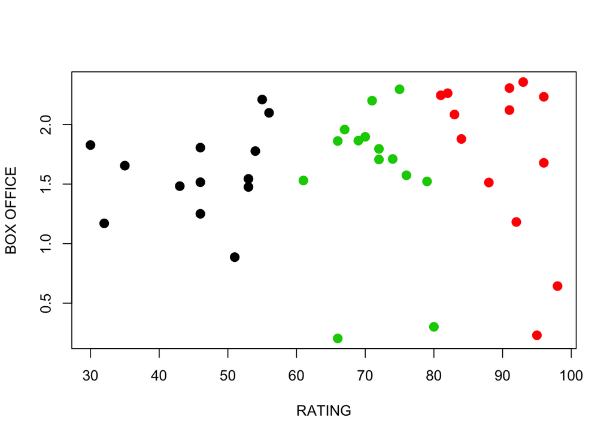

```r
#k <- kmeans(filmes, 3)
dat <- filmes2[,c(1,4)]

#plot(dat, pch = 20, cex = 2)
set.seed(7)
km1 <- kmeans(dat, 3)
plot(dat, col = km1$cluster, pch = 20, cex = 2)
```

O plot standardize facilita a visualizaçao dos clusters.

Considerando os plots acima, é possivel notar que o ator Matt Damon participa de muitos filmes de alta rentabilidade, a principal diferenca entre os tres grupos esta nas notas atribuidas pelo rotten tomatoes.

1. Jason Bourne franquia (vermelho) - nesse grupo estao a maioria dos seus filmes mais rentaveis e de maior rating,como The Bourne Ultimatum e The Martian. Nesse grupo o ator foi o personagem principal em maior parte dos filmes deste grupo.
2. Happy Feet (verde) - Os filmes desse grupos ainda tem boa rentabilidade e rating mediano, porem o ator nao recebeu papeis de grande destaque como no primeiro grupo. Um dos filmes do grupo 2 é Interstellar
3. The Great Wall(preto) - Neste grupo estao os filmes com uma rentabilidade um pouco menor e menor rating, como Happy Feet Two.